# Shah_Shrey_DataViz_Assignment-2_Code

# Total Square Footage as function of Congress District

```python
data_filtered[['Congress Dist', 'Square Footage']]
```

|  | Congress Dist | Square Footage |
| --- | --- | --- |
| 0 | 17 | 144 |
| 1 | 17 | 144 |
| 2 | 17 | 144 |
| 3 | 17 | 144 |
| 4 | 17 | 144 |
| ... | ... | ... |
| 8851 | 17 | 1455 |
| 8852 | 4 | 6720 |
| 8853 | 12 | 760 |
| 8854 | 12 | 760 |
| 8860 | 16 | 49552 |

8393 rows × 2 columns

```python
# Displaying the unique values in 'Congress Dist'

data_filtered['Congress Dist'].unique()
```

```
array([17, 15, 16, 18, 11, 12,  3, 13,  6,  0, 14,  7,  8,  9,  2,  1, 10,
        5,  4])
```

```python
# Displaying the value counts in 'Congress Dist'

data_filtered['Square Footage'].value_counts()
```

```
144       358
20        125
75        122
100        79
2400       76
         ...
22350       1
347981      1
34636       1
132916      1
28430       1
Name: Square Footage, Length: 3025, dtype: int64
```

```python
# Finding the sum of 'Square Footage' and group it by the 'Congress Dist'

df_Total_Square_Footage_Congress_Dist = data_filtered.groupby('Congress Dist')[['Square Footage']].sum()
```

```python
# Return the total sum of Square Footage per Congress Dist

df_Total_Square_Footage_Congress_Dist
```

| Congress Dist | Square Footage |
| --- | --- |
| 0 | 774972 |
| 1 | 2324262 |
| 2 | 6237304 |
| 3 | 1151487 |
| 4 | 316234 |
| 5 | 1623497 |
| 6 | 145659 |
| 7 | 9125943 |
| 8 | 1461512 |
| 9 | 69750 |
| 10 | 824097 |
| 11 | 3462039 |
| 12 | 12195511 |
| 13 | 29917372 |
| 14 | 820540 |
| 15 | 6610872 |
| 16 | 8567535 |
| 17 | 4190441 |
| 18 | 8056628 |

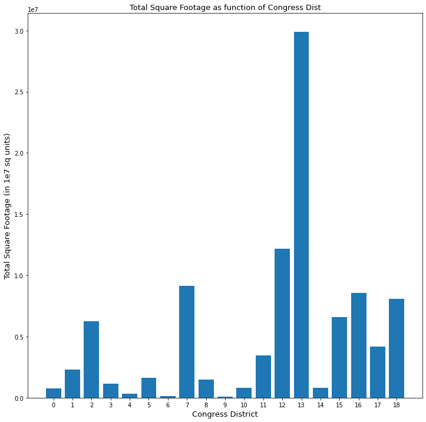

```python
# Plotting the total Square Footage variable for each Congress Dist

fig, ax = plt.subplots(figsize=(12,12))
ax.bar(df_Total_Square_Footage_Congress_Dist.index, df_Total_Square_Footage_Congress_Dist['Square Footage'])
ax.set_xticks([i for i in range(0,19)])
ax.set_xlabel("Congress District", fontsize=13)
ax.set_ylabel("Total Square Footage (in 1e7 sq units)", fontsize=13)
ax.set_title("Total Square Footage as function of Congress Dist", fontsize=13)

plt.show()
```

- For this problem, we need to find the sum of all square footage areas for each congress district.
- I have checked before and there are no null values in both 'Congress Dist' and 'Square Footage'.
- The 'Congress Dist' is a categorical variable and the 'Square Footage' is a numberical variable.
- I found the unique values for Congress Dist variable and see that there are 19 values from 0 to 18.
- I created a new variable where I am calculating the sum of Square Footage for each Congress Dist and group according to the Congress Dist.
- I have then used a bar chart to plot the total Square Footage against the categorical Congress Dist and set the labels because the Congress Dist can be considered as a categorical variable and the area as numeric. As far as I think there is no shortcoming for this question and I have successfuly been able to provide an informative visualization.